# 11_LASSO_ALT_status

Andrea Polazzi

2026-03-25

# Setup

```r
library(readxl)
library(tidyverse)
library(pROC)
library(glmnet)

source('../scripts/clean_columns.R')

data <- read_xlsx('../data/raw/PCAWG_variables_PCA_woK.xlsx')
clean_data <- clean_pcawg_data(data)

# Complete cases only, drop sample ID columns
model_data <- clean_data[complete.cases(clean_data), -c(1, 2)]
summary(model_data)
```

```
##     alt_status     tf_rate         telomere_insertion_rate
##  ALT-low :768   Min.   : 0.00000   Min.   :0.00000
##  ALT-high: 49   1st Qu.: 0.00000   1st Qu.:0.00000
##                 Median : 0.03147   Median :0.00000
##                 Mean   : 0.12777   Mean   :0.03592
##                 3rd Qu.: 0.07243   3rd Qu.:0.01934
##                 Max.   :19.73776   Max.   :3.46027
##  telomere_content_log2   TERT_FPKM        ATAGGG_singleton_dist
##  Min.   :-2.29092      Min.   : 0.00000   Min.   :-3.82135
##  1st Qu.:-0.95324      1st Qu.: 0.02014   1st Qu.:-0.56491
##  Median :-0.55712      Median : 0.10907   Median : 0.02487
##  Mean   :-0.44621      Mean   : 0.91717   Mean   : 0.01321
##  3rd Qu.:-0.08914      3rd Qu.: 0.39077   3rd Qu.: 0.59111
##  Max.   : 3.84469      Max.   :53.76790   Max.   : 4.47470
##  CTAGGG_singleton_dist GTAGGG_singleton_dist TAAGGG_singleton_dist
##  Min.   :-3.0401       Min.   :-2.43840      Min.   :-3.13241
##  1st Qu.:-0.2686       1st Qu.:-0.32314      1st Qu.:-0.53764
##  Median : 0.1495       Median : 0.03610      Median : 0.10627
##  Mean   : 0.1797       Mean   : 0.03857      Mean   : 0.07596
##  3rd Qu.: 0.6213       3rd Qu.: 0.33915      3rd Qu.: 0.69820
##  Max.   : 2.8541       Max.   : 2.74981      Max.   : 3.81679
##  TCAGGG_singleton_dist TGAGGG_singleton_dist TTCGGG_singleton_dist
##  Min.   :-2.8553       Min.   :-5.27154      Min.   :-3.23509
##  1st Qu.:-0.4778       1st Qu.:-0.35882      1st Qu.:-0.48603
##  Median : 0.1182       Median : 0.07551      Median : 0.09028
##  Mean   : 0.1982       Mean   : 0.10597      Mean   : 0.15567
##  3rd Qu.: 0.7847       3rd Qu.: 0.46824      3rd Qu.: 0.66142
##  Max.   : 7.5686       Max.   : 6.67267      Max.   : 8.73932
##  TTGGGG_singleton_dist TTTGGG_singleton_dist
##  Min.   :-3.02421      Min.   :-3.80780
##  1st Qu.:-0.36756      1st Qu.:-0.40600
##  Median :-0.01286      Median : 0.02340
##  Mean   : 0.02180      Mean   : 0.00976
##  3rd Qu.: 0.44543      3rd Qu.: 0.48155
##  Max.   : 3.19366      Max.   : 2.25362
```

# Motivation

The previous analyses (PCA, Random Forest, feature ablation) identified a set of predictors relevant to ALT-high/ALT-low classification, but using methods that do not provide formal effect size estimates or automatic variable selection. LASSO-penalized logistic regression instead does:

- **automatic variable selection** via shrinkage of coefficients to zero
- **effect sizes on a common scale** when predictors are pre-standardized
- **regularization** that reduces overfitting, particularly useful in the presence of correlated predictors (such as TVR motifs)

# Data preparation

Before passing data to `cv.glmnet`, we explicitly standardize the predictor matrix. This is necessary to make LASSO coefficients comparable across variables on different scales (e.g. `TERT_FPKM` vs `telomere_insertion_rate`). We then disable the internal standardization in `glmnet` to avoid double transformation.

```r
X <- scale(as.matrix(model_data[, -1]))
y <- model_data$alt_status
```

We verify the distribution of the response variable to document class imbalance.

```r
table(y, dnn = "ALT status")
```

```
## ALT status
##  ALT-low ALT-high
##      768       49
```

# Cross-validation for λ selection

We use `cv.glmnet` with 10 folds and `alpha = 1` (pure LASSO). The optimized metric is binomial deviance. We evaluate two standard thresholds:

- **`lambda.min`**: λ minimizing CV error — richer model, maximum predictive performance
- **`lambda.1se`**: λ within 1 SE of the minimum — more parsimonious model, preferable for biological interpretation

```r
set.seed(21)
cv_fit <- cv.glmnet(
  X, y,
  alpha = 1,
  family = "binomial",
  standardize = FALSE,  # already standardized manually
  nfolds = 10,
  keep = TRUE    # enables fit.preval for out-of-fold predictions
)
```

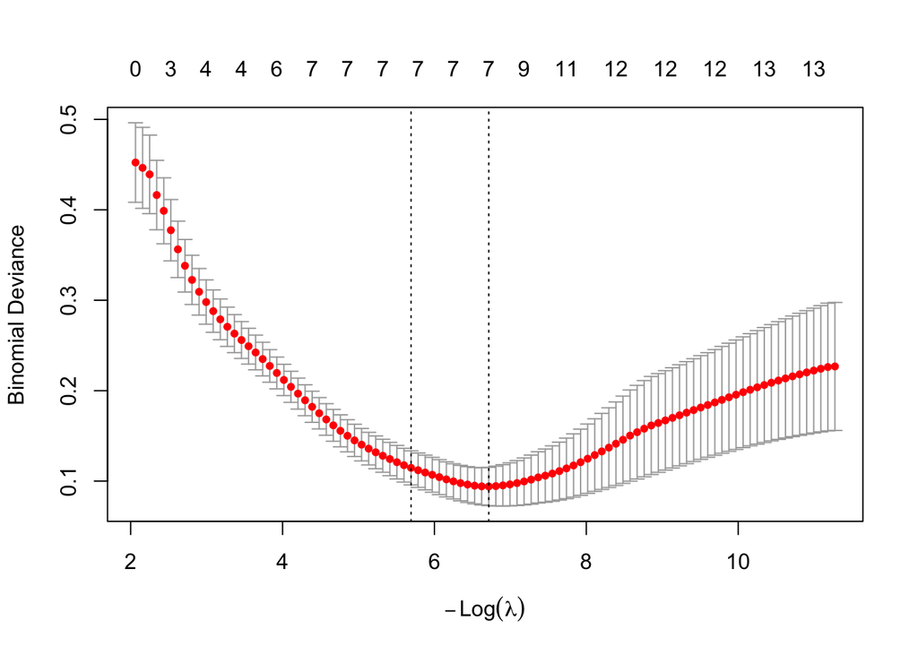

```r
plot(cv_fit)
```

```r
cat("lambda.min:", cv_fit$lambda.min, "\n")
```

```
## lambda.min: 0.001212101
```

```r
cat("lambda.1se:", cv_fit$lambda.1se, "\n")
```

```
## lambda.1se: 0.003372744
```

# LASSO coefficients

We have seen that both values for λ correspond to 7 predictors retained, but are they the same 7?

We extract and compare coefficients at both λ values. The main biological interest lies in the **selection** (which variables are sent to 0) and in the **directions and relative magnitudes** of non-zero coefficients.

```r
coef_min <- coef(cv_fit, s = "lambda.min")
coef_1se <- coef(cv_fit, s = "lambda.1se")

# Build a comparison dataframe, excluding the intercept
coef_df <- data.frame(
  feature    = rownames(coef_min)[-1],
  lambda_min = as.numeric(coef_min)[-1],
  lambda_1se = as.numeric(coef_1se)[-1]
) %>%
  mutate(
    selected_min = lambda_min != 0,
    selected_1se = lambda_1se != 0,
    feature = gsub("_singleton_dist", "", feature)  # cleaner labels
  ) %>%
  arrange(desc(abs(lambda_1se)))

print(coef_df)
```

```
##                    feature  lambda_min  lambda_1se selected_min selected_1se
## 1  telomere_insertion_rate 11.04722800  5.66715053         TRUE         TRUE
## 2                   TGAGGG  2.57329844  1.69165560         TRUE         TRUE
## 3                   TTTGGG -1.85392204 -1.22794718         TRUE         TRUE
## 4                   ATAGGG  0.36900495  0.24499286         TRUE         TRUE
## 5                TERT_FPKM  0.27424220  0.22163491         TRUE         TRUE
## 6                   TAAGGG  0.24439609  0.09564118         TRUE         TRUE
## 7                   TCAGGG  0.00000000  0.03879733        FALSE         TRUE
## 8                  tf_rate  0.00000000  0.00000000        FALSE        FALSE
## 9    telomere_content_log2  0.00000000  0.00000000        FALSE        FALSE
## 10                  CTAGGG  0.00000000  0.00000000        FALSE        FALSE
## 11                  GTAGGG -0.08454882  0.00000000         TRUE        FALSE
## 12                  TTCGGG  0.00000000  0.00000000        FALSE        FALSE
## 13                  TTGGGG  0.00000000  0.00000000        FALSE        FALSE
```

## Coefficient visualization

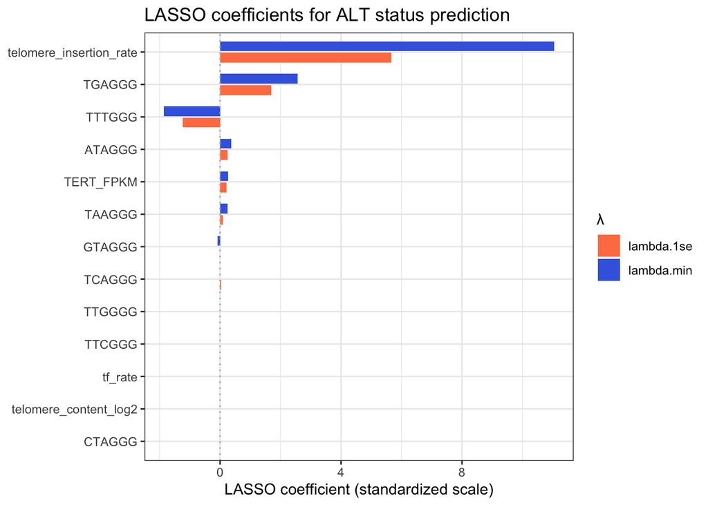

Standardized LASSO coefficients at both λ values. Zero values indicate variables excluded from the model.

```r
coef_long <- coef_df %>%
  pivot_longer(
    cols = c(lambda_min, lambda_1se),
    names_to = "lambda",
    values_to = "coefficient"
  ) %>%
  mutate(
    lambda  = recode(lambda,
                     lambda_min = "lambda.min",
                     lambda_1se = "lambda.1se"),
    feature = reorder(feature, abs(coefficient))
  )

ggplot(coef_long, aes(x = coefficient, y = feature, fill = lambda)) +
  geom_col(position = position_dodge(width = 0.7), width = 0.6) +
  geom_vline(xintercept = 0, linetype = "dotted", color = "grey70") +
  scale_fill_manual(values = c("lambda.min" = "royalblue", "lambda.1se" = "coral")) +
  theme_bw() +
  labs(
    x = "LASSO coefficient (standardized scale)",
    y = NULL,
    fill = "λ",
    title = "LASSO coefficients for ALT status prediction"
  )
```

Both lambda values agree on the majority of predictors, apart from the TVR motifs **GTAGGG (only present for lambda.min)** and **TCAGGG (present only for lambda.1se)**. Their borderline contribution should be discussed, to decide whether they can be considered as meaningful predictors or unstable ones coming from λ value perturbations.

**Telomere insertion** confirmes itself again as a **strong predictor**.

# Distribution of `telomere_insertion_rate`

The large coefficient of `telomere_insertion_rate` suggests very strong class separation. We visualize its distribution to assess whether near-perfect separation is occurring, which would cause coefficient inflation even after regularization.

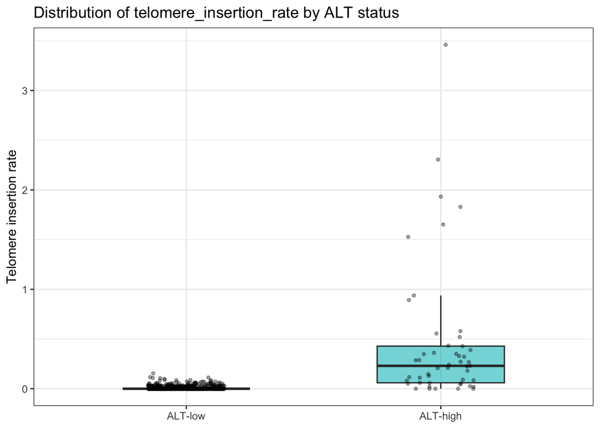

```r
ggplot(model_data, aes(x = alt_status, y = telomere_insertion_rate, fill = alt_status)) +
  geom_boxplot(outlier.shape = NA, alpha = 0.6, width = 0.5) +
  geom_jitter(width = 0.15, alpha = 0.35, size = 1) +
  theme_bw() +
  labs(
    x     = NULL,
    y     = "Telomere insertion rate",
    title = "Distribution of telomere_insertion_rate by ALT status"
  ) +
  theme(legend.position = "none")
```

The boxplot shows that **ALT-low samples are tightly concentrated near zero**, while **ALT-high samples have substantially higher and more variable values**, extending well above 1. There is minimal overlap between the main distributions, indicating **strong separation** between groups based on this feature.

# Predictive performance

We evaluate the LASSO model with `lambda.1se` via ROC/AUC. Since CV was already performed for λ selection, we use the out-of-fold predictions stored in `cv_fit$fit.preval` for an unbiased performance estimate. Using these instead of refitting on the full dataset avoids the optimistic bias that would arise from evaluating on training data.

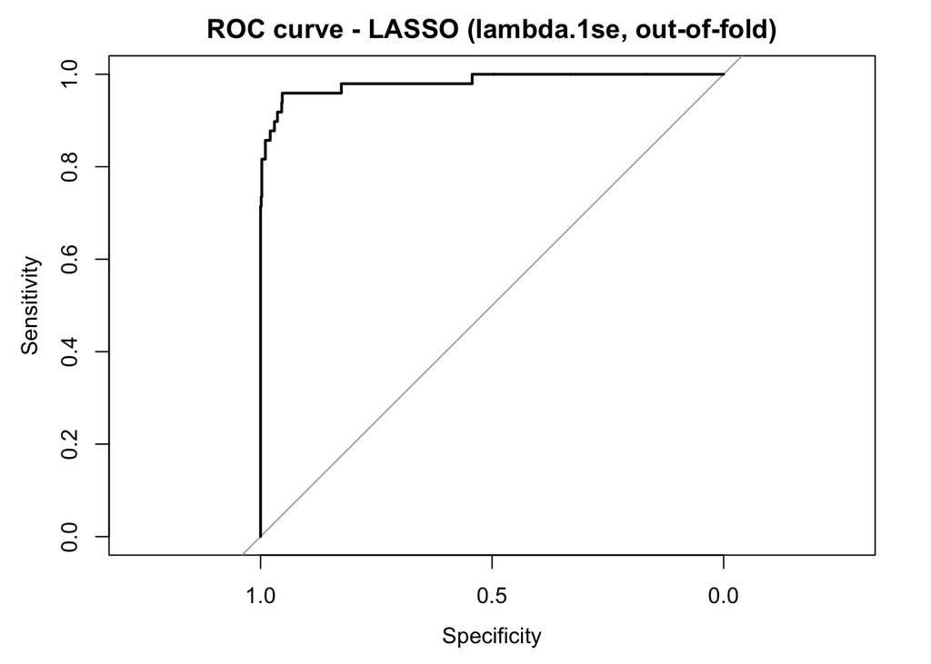

```r
# Index of lambda.1se in the path (robust to floating point)
idx_1se   <- which.min(abs(cv_fit$lambda - cv_fit$lambda.1se))
oof_probs <- cv_fit$fit.preval[, idx_1se]

roc_lasso <- roc(
  response  = y,
  predictor = oof_probs,
  levels    = c("ALT-low", "ALT-high"),
  direction = "<"
)

plot(roc_lasso,
     main = "ROC curve - LASSO (lambda.1se, out-of-fold)",
     xlim = c(1, 0))
```

```r
cat("AUC (out-of-fold, lambda.1se):", round(auc(roc_lasso), 4), "\n")
```

```
## AUC (out-of-fold, lambda.1se): 0.9828
```

The ROC curve rises sharply, achieving **high sensitivity** at **near-perfect specificity**. This indicates strong discriminative performance, with the model accurately separating ALT-high from ALT-low samples based on predicted probabilities. The **AUC value is 0.9828**.

# Post-selection refitting

LASSO coefficients are biased toward zero by construction and cannot be used as formal effect sizes. The standard approach is to refit an ordinary logistic regression on the variables selected by `lambda.1se` (*post-selection refitting*), which yields unpenalized coefficients with standard errors and interpretable p-values.

```r
# Reconstruct original column names for TVR motifs
selected <- coef_df %>%
  filter(selected_1se) %>%
  pull(feature) %>%
  gsub("ATAGGG", "ATAGGG_singleton_dist", .) %>%
  gsub("TAAGGG", "TAAGGG_singleton_dist", .) %>%
  gsub("TCAGGG", "TCAGGG_singleton_dist", .) %>%
  gsub("TGAGGG", "TGAGGG_singleton_dist", .) %>%
  gsub("TTTGGG", "TTTGGG_singleton_dist", .)

cat("Variables selected by lambda.1se:\n")
```

```
## Variables selected by lambda.1se:
```

```r
print(selected)
```

```
## [1] "telomere_insertion_rate" "TGAGGG_singleton_dist"
## [3] "TTTGGG_singleton_dist"   "ATAGGG_singleton_dist"
## [5] "TERT_FPKM"               "TAAGGG_singleton_dist"
## [7] "TCAGGG_singleton_dist"
```

```r
model_sel <- model_data[, c("alt_status", selected)]
post_fit  <- glm(alt_status ~ ., data = model_sel, family = "binomial")
summary(post_fit)
```

```
##
## Call:
## glm(formula = alt_status ~ ., family = "binomial", data = model_sel)
##
## Coefficients:
##                          Estimate Std. Error z value Pr(>|z|)
## (Intercept)             -14.12945    3.22466  -4.382 1.18e-05 ***
## telomere_insertion_rate 130.61982   32.41786   4.029 5.60e-05 ***
## TGAGGG_singleton_dist     7.13632    1.99070   3.585 0.000337 ***
## TTTGGG_singleton_dist    -5.33049    1.36208  -3.914 9.10e-05 ***
## ATAGGG_singleton_dist     0.60100    0.49561   1.213 0.225268
## TERT_FPKM                 0.13093    0.07807   1.677 0.093550 .
## TAAGGG_singleton_dist     0.45034    0.41947   1.074 0.283008
## TCAGGG_singleton_dist    -0.57234    0.46353  -1.235 0.216925
## ---
## Signif. codes:  0 '***' 0.001 '**' 0.01 '*' 0.05 '.' 0.1 ' ' 1
##
## (Dispersion parameter for binomial family taken to be 1)
##
##     Null deviance: 370.755  on 816  degrees of freedom
## Residual deviance:  37.592  on 809  degrees of freedom
## AIC: 53.592
##
## Number of Fisher Scoring iterations: 12
```

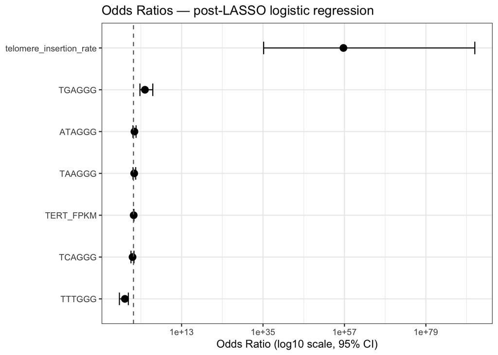

Odds ratios and 95% confidence intervals for variables selected by LASSO (post-selection refitting). Log scale.

```r
or_df <- data.frame(
  feature = names(coef(post_fit))[-1],
  OR = exp(coef(post_fit))[-1],
  CI_low = exp(confint(post_fit))[-1, 1],
  CI_high = exp(confint(post_fit))[-1, 2]
) %>%
  mutate(feature = gsub("_singleton_dist", "", feature)) %>%
  arrange(OR)

ggplot(or_df, aes(x = OR, y = reorder(feature, OR))) +
  geom_point(size = 3) +
  geom_errorbarh(aes(xmin = CI_low, xmax = CI_high), height = 0.3) +
  geom_vline(xintercept = 1, linetype = "dashed", color = "grey40") +
  scale_x_log10() +
  theme_bw() +
  labs(
    x = "Odds Ratio (log10 scale, 95% CI)",
    y = NULL,
    title = "Odds Ratios — post-LASSO logistic regression"
  )
```

# Summary

```r
summary_table <- coef_df %>%
  filter(selected_1se) %>%
  select(feature, lambda_min, lambda_1se) %>%
  mutate(
    across(where(is.numeric), ~ round(.x, 3)),
    association = ifelse(lambda_1se > 0, "ALT-high", "ALT-low")
  )

knitr::kable(
  summary_table,
  col.names = c("Feature", "Coeff. lambda.min", "Coeff. lambda.1se", "Association"),
  caption   = "Variables selected by LASSO (lambda.1se) with standardized coefficients and direction of association with ALT status."
)
```

Variables selected by LASSO (lambda.1se) with standardized coefficients and direction of association with ALT status.

| Feature | Coeff. lambda.min | Coeff. lambda.1se | Association |
| --- | --- | --- | --- |
| telomere_insertion_rate | 11.047 | 5.667 | ALT-high |
| TGAGGG | 2.573 | 1.692 | ALT-high |
| TTTGGG | -1.854 | -1.228 | ALT-low |
| ATAGGG | 0.369 | 0.245 | ALT-high |
| TERT_FPKM | 0.274 | 0.222 | ALT-high |
| TAAGGG | 0.244 | 0.096 | ALT-high |
| TCAGGG | 0.000 | 0.039 | ALT-high |